# Exercício: SARIMA no comércio varejista brasileiro (São Paulo)

## Sobre o exercício

A base é a PMC (Pesquisa Mensal do Comércio) do IBGE: índice de volume de vendas no comércio varejista ampliado, por UF, mensal desde jan/2004, base 2022 = 100, sem ajuste sazonal. A UF escolhida foi São Paulo.

## Setup

```python
import warnings
warnings.filterwarnings("ignore")

import numpy as np
import pandas as pd
import matplotlib.pyplot as plt

from statsmodels.tsa.stattools import adfuller, kpss
from statsmodels.graphics.tsaplots import plot_acf, plot_pacf
from statsmodels.stats.diagnostic import acorr_ljungbox

from statsforecast import StatsForecast
from statsforecast.models import AutoARIMA
from statsforecast.arima import arima_string, ndiffs, nsdiffs
```

## Carregando a base PMC

```python
pmc = pd.read_csv("https://github.com/padsInsper/202634-fa/releases/download/data/pmc_volume_uf.csv")
```

## Escolha da UF

```python
MINHA_UF = "São Paulo"

df_sf = (
    pmc.query("uf == @MINHA_UF")
    .rename(columns={"uf": "unique_id", "data": "ds", "volume_idx": "y"})
    [["unique_id", "ds", "y"]]
    .reset_index(drop=True)
)
df_sf["ds"] = pd.to_datetime(df_sf["ds"])

# série com a data no índice, mais fácil para gráficos e testes
serie = df_sf.set_index("ds")["y"]

df_sf.head()
```

|  | unique_id | ds | y |
| --- | --- | --- | --- |
| 0 | São Paulo | 2004-01-01 | 52.53519 |
| 1 | São Paulo | 2004-02-01 | 50.98433 |
| 2 | São Paulo | 2004-03-01 | 57.18775 |
| 3 | São Paulo | 2004-04-01 | 54.76454 |
| 4 | São Paulo | 2004-05-01 | 57.09082 |

```python
print(f"{len(serie)} meses, de {serie.index.min():%m/%Y} a {serie.index.max():%m/%Y}")
```

```
266 meses, de 01/2004 a 02/2026
```

## Análise descritiva

### Gráfico de linha

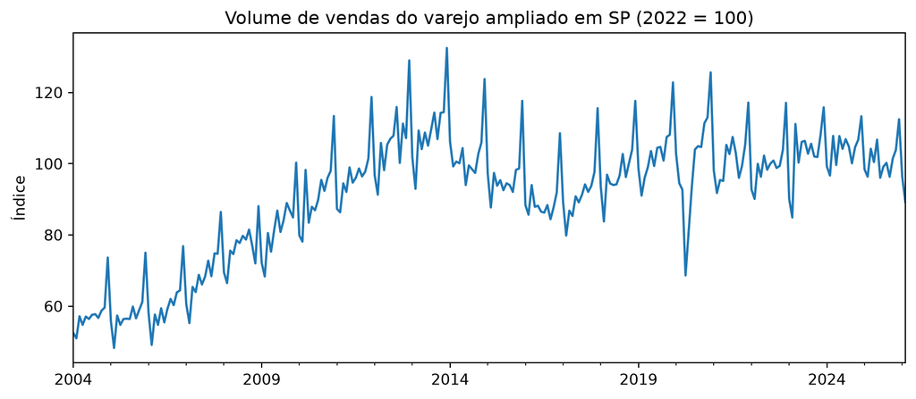

```python
fig, ax = plt.subplots(figsize=(10, 4))
serie.plot(ax=ax)
ax.set_title("Volume de vendas do varejo ampliado em SP (2022 = 100)")
ax.set_xlabel("")
ax.set_ylabel("Índice")
plt.show()
```

A série sobe bastante de 2004 até 2013/2014, cai forte em 2015 e 2016 (recessão) e depois volta a subir aos poucos, ficando perto de 100 desde 2019. Em 2020 tem a queda brusca de abril, da pandemia. Dá para ver também um padrão que se repete todo ano, com pico em dezembro.

### Média por mês do ano

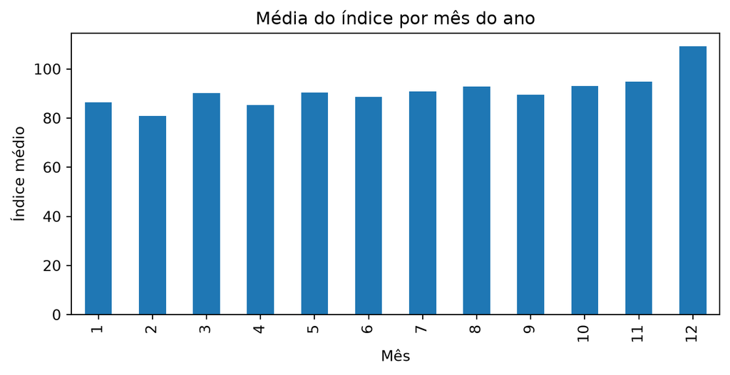

```python
media_mes = serie.groupby(serie.index.month).mean()

fig, ax = plt.subplots(figsize=(8, 3.5))
media_mes.plot(kind="bar", ax=ax)
ax.set_title("Média do índice por mês do ano")
ax.set_xlabel("Mês")
ax.set_ylabel("Índice médio")
plt.show()
```

Dezembro é bem mais alto que os outros meses, por causa do Natal e do 13º salário. Fevereiro é o mês mais fraco, porque tem menos dias e tem Carnaval. Isso confirma a sazonalidade anual.

### ACF e PACF da série original

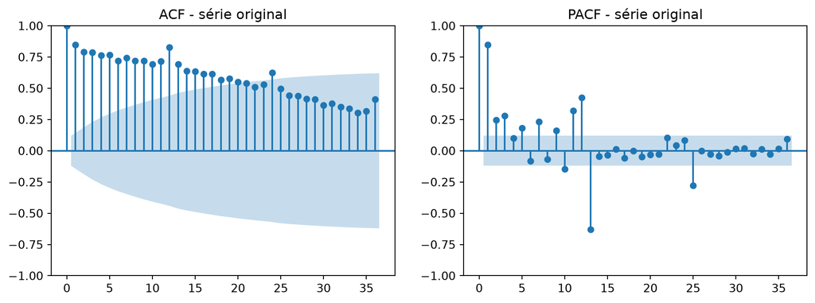

```python
fig, ax = plt.subplots(1, 2, figsize=(12, 4))
plot_acf(serie, lags=36, ax=ax[0])
plot_pacf(serie, lags=36, ax=ax[1], method="ywm")
ax[0].set_title("ACF - série original")
ax[1].set_title("PACF - série original")
plt.show()
```

A ACF cai bem devagar e fica alta mesmo depois de 36 lags, o que indica que a série não é estacionária (tem tendência). Também aparecem picos nos lags 12, 24 e 36, sinal de sazonalidade anual. A PACF tem um pico grande no lag 1, típico de série com tendência.

### Diferenciação

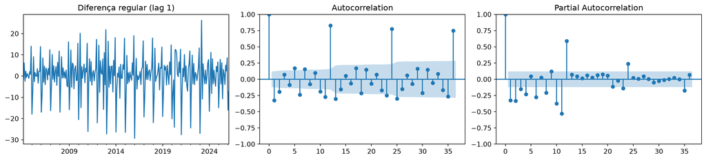

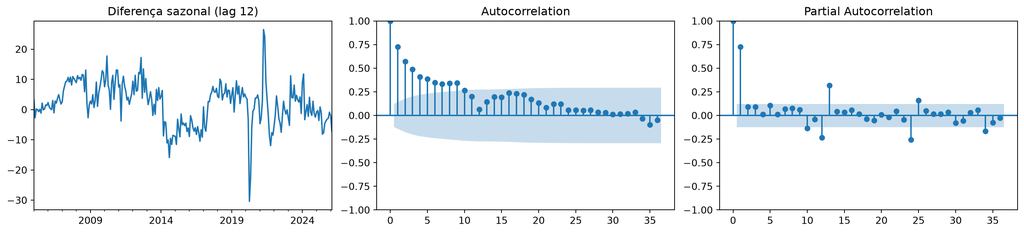

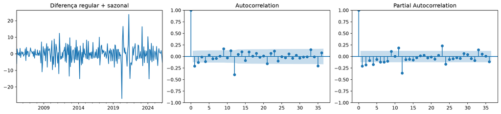

```python
versoes = {
    "Diferença regular (lag 1)": serie.diff(1).dropna(),
    "Diferença sazonal (lag 12)": serie.diff(12).dropna(),
    "Diferença regular + sazonal": serie.diff(12).diff(1).dropna(),
}

for nome, x in versoes.items():
    fig, ax = plt.subplots(1, 3, figsize=(15, 3.5))
    x.plot(ax=ax[0])
    ax[0].set_title(nome)
    ax[0].set_xlabel("")
    plot_acf(x, lags=36, ax=ax[1])
    plot_pacf(x, lags=36, ax=ax[2], method="ywm")
    plt.tight_layout()
    plt.show()
```

- Só com a diferença regular, a tendência some, mas a ACF ainda tem picos fortes nos lags 12, 24 e 36. Ou seja, a sazonalidade continua.
- Só com a diferença sazonal, a série ainda anda devagar para cima e para baixo (a ACF demora a cair), então sobra um pouco de tendência.
- Com as duas diferenças juntas, a série fica oscilando em torno de zero. A ACF tem um pico negativo no lag 1 e outro no lag 12, o que sugere um componente MA regular e um MA sazonal.

## Testes de raiz unitária

```python
def testes(x, nome):
    adf_p = adfuller(x, autolag="AIC")[1]
    kpss_p = kpss(x, regression="c", nlags="auto")[1]
    return {"série": nome, "ADF p-valor": round(adf_p, 4), "KPSS p-valor": round(kpss_p, 4)}

tabela = pd.DataFrame(
    [testes(serie, "Original")] + [testes(x, nome) for nome, x in versoes.items()]
)
tabela
```

|  | série | ADF p-valor | KPSS p-valor |
| --- | --- | --- | --- |
| 0 | Original | 0.2111 | 0.0100 |
| 1 | Diferença regular (lag 1) | 0.0000 | 0.1000 |
| 2 | Diferença sazonal (lag 12) | 0.1253 | 0.0362 |
| 3 | Diferença regular + sazonal | 0.0000 | 0.1000 |

Lembrando que os dois testes têm hipóteses nulas opostas:

- ADF: H0 = tem raiz unitária (não estacionária). p-valor baixo é bom.
- KPSS: H0 = é estacionária. p-valor alto é bom.

Na série original o ADF não rejeita (p > 0,05) e o KPSS rejeita (p < 0,05), então os dois concordam que ela não é estacionária. Com a diferença regular, ou com as duas diferenças, o ADF rejeita e o KPSS não rejeita, então a série fica estacionária. Obs: o KPSS só calcula p-valor entre 0,01 e 0,10, por isso aparecem esses valores “travados”.

```python
print("ndiffs (diferenças regulares):", ndiffs(serie.values))
print("nsdiffs (diferenças sazonais):", nsdiffs(serie.values, period=12))
```

```
ndiffs (diferenças regulares): 1
nsdiffs (diferenças sazonais): 1
```

O `ndiffs` sugere 1 diferença regular e o `nsdiffs` sugere 1 diferença sazonal, o que bate com a análise acima.

## Modelagem

```python
sf = StatsForecast(models=[AutoARIMA(season_length=12)], freq="MS")
sf.fit(df_sf)

modelo = sf.fitted_[0, 0].model_
print(arima_string(modelo))
print()
print("Coeficientes:")
for nome, valor in modelo["coef"].items():
    print(f"  {nome}: {valor:.3f}")
print(f"AICc: {modelo['aicc']:.1f}")
```

```
ARIMA(2,1,1)(0,1,1)[12]

Coeficientes:
  ar1: 0.507
  ar2: 0.002
  ma1: -0.802
  sma1: -0.859
AICc: 1446.5
```

O AutoARIMA escolheu um **SARIMA(2,1,1)(0,1,1)[12]**:

- d = 1 e D = 1: uma diferença regular e uma sazonal, igual ao que os testes e o `ndiffs` indicaram.
- AR(2) e MA(1) na parte regular. O coeficiente do ar2 é praticamente zero, então na prática o AR que importa é o ar1.
- MA(1) sazonal, com coeficiente forte (perto de -0,86). Isso combina com o pico negativo no lag 12 da ACF da série diferenciada.

## Diagnóstico dos resíduos

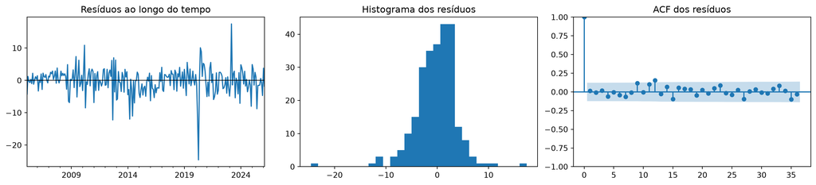

```python
residuos = pd.Series(modelo["residuals"], index=serie.index)
# os 13 primeiros resíduos são "perdidos" com as diferenças (1 + 12)
residuos = residuos.iloc[13:]

fig, ax = plt.subplots(1, 3, figsize=(15, 3.5))
residuos.plot(ax=ax[0])
ax[0].axhline(0, color="black", linewidth=0.8)
ax[0].set_title("Resíduos ao longo do tempo")
ax[0].set_xlabel("")
ax[1].hist(residuos, bins=30)
ax[1].set_title("Histograma dos resíduos")
plot_acf(residuos, lags=36, ax=ax[2])
ax[2].set_title("ACF dos resíduos")
plt.tight_layout()
plt.show()
```

```python
acorr_ljungbox(residuos, lags=[12, 24])
```

|  | lb_stat | lb_pvalue |
| --- | --- | --- |
| 12 | 15.991189 | 0.191640 |
| 24 | 25.391709 | 0.384732 |

Os resíduos ficam em torno de zero e, na ACF, só o lag 12 passa um pouco da banda (cerca de 0,16). O teste de Ljung-Box não rejeita a hipótese de ruído branco (p-valor de 0,19 no lag 12 e 0,38 no lag 24). Então o modelo capturou bem a tendência e a maior parte da sazonalidade. O ponto fora da curva é abril de 2020 (pandemia), que nenhum modelo desse tipo consegue prever, e o histograma tem caudas um pouco mais pesadas por causa desses choques.

## Previsão · 24 meses à frente

```python
previsao = sf.predict(h=24, level=[80, 95])
previsao.head()
```

|  | unique_id | ds | AutoARIMA | AutoARIMA-lo-95 | AutoARIMA-lo-80 | AutoARIMA-hi-80 | AutoARIMA-hi-95 |
| --- | --- | --- | --- | --- | --- | --- | --- |
| 0 | São Paulo | 2026-03-01 | 99.642480 | 91.731911 | 94.470037 | 104.814924 | 107.553050 |
| 1 | São Paulo | 2026-04-01 | 94.088640 | 84.411555 | 87.761135 | 100.416146 | 103.765725 |
| 2 | São Paulo | 2026-05-01 | 100.226679 | 89.594243 | 93.274503 | 107.178855 | 110.859115 |
| 3 | São Paulo | 2026-06-01 | 97.712546 | 86.418684 | 90.327887 | 105.097205 | 109.006407 |
| 4 | São Paulo | 2026-07-01 | 100.287844 | 88.462957 | 92.555966 | 108.019722 | 112.112732 |

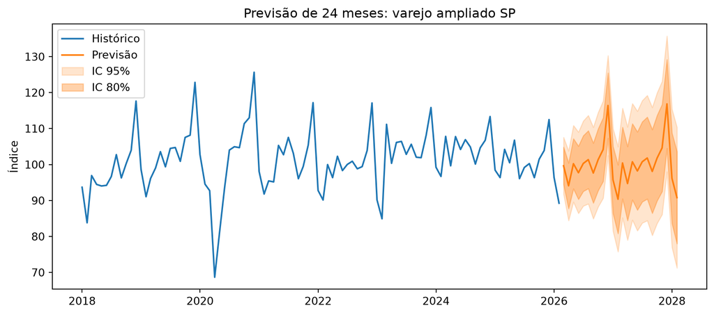

```python
historico = df_sf[df_sf["ds"] >= "2018-01-01"]

fig, ax = plt.subplots(figsize=(11, 4.5))
ax.plot(historico["ds"], historico["y"], label="Histórico")
ax.plot(previsao["ds"], previsao["AutoARIMA"], label="Previsão")
ax.fill_between(previsao["ds"], previsao["AutoARIMA-lo-95"], previsao["AutoARIMA-hi-95"],
                alpha=0.2, color="tab:orange", label="IC 95%")
ax.fill_between(previsao["ds"], previsao["AutoARIMA-lo-80"], previsao["AutoARIMA-hi-80"],
                alpha=0.35, color="tab:orange", label="IC 80%")
ax.set_title("Previsão de 24 meses: varejo ampliado SP")
ax.set_ylabel("Índice")
ax.legend(loc="upper left")
plt.show()
```

A previsão repete o padrão sazonal da série (pico em dezembro e queda em fevereiro) e fica no mesmo nível dos últimos anos, perto de 100. Os intervalos abrem conforme o horizonte aumenta, o que é esperado, já que o erro vai se acumulando mês a mês.

## Discussão

**1. O ACF/PACF da série original sugeriu sazonalidade? E tendência? Bate com o gráfico de linha?** Sim para os dois. A ACF cai bem devagar (tendência) e tem picos nos lags 12, 24 e 36 (sazonalidade anual). Bate com o gráfico de linha, que mostra a subida até 2014 e o pico de vendas todo dezembro.

**2. Quantas diferenças o AutoARIMA aplicou? E os componentes AR/MA? Deu para ver no ACF/PACF?** Ele aplicou uma diferença regular e uma sazonal (d = 1, D = 1), e escolheu AR(2) e MA(1) na parte regular e MA(1) sazonal. Na série com as duas diferenças, a ACF tem pico negativo no lag 1 e no lag 12, o que bate com o MA(1) e o MA(1) sazonal. O AR(2) é mais difícil de ver no gráfico, e o próprio coeficiente do ar2 saiu perto de zero.

**3. Os resíduos parecem white noise? Sobrou algum padrão sazonal?** No geral, sim. O Ljung-Box não rejeita ruído branco nos lags 12 e 24. Sobrou só uma autocorrelação pequena no lag 12, um pouco acima da banda, então pode ter um resto de sazonalidade que o MA sazonal não pegou totalmente, mas nada forte. Fora isso aparecem alguns choques isolados, como abril de 2020.

**4. A previsão pareceu razoável?** Sim. Ela captura a sazonalidade, fica ancorada no nível recente da série e os intervalos abrem com o horizonte, como esperado. O modelo só não consegue prever choques como uma crise ou uma pandemia, então a previsão vale para um cenário “normal”.

**5. Que outras UFs dariam um SARIMA bem diferente?** Estados pequenos e com economia menos diversificada, como Roraima, Amapá e Acre, devem ter séries mais voláteis e com tendência mais forte (cresceram muito desde 2004 partindo de uma base baixa), então o modelo pode precisar de outra ordem. Estados agrícolas, como Mato Grosso, podem ter um ciclo ligado à safra e à venda de máquinas e veículos. Estados turísticos do Nordeste ou Santa Catarina podem ter uma sazonalidade mais concentrada no verão, diferente do padrão de SP, que é dominado pelo Natal.